# Transformations, Forecasting and Bias Correction

## Small-Group Activity: Retail Sales (20 min)

Figure 5 gives the total sales (in millions of U.S. dollars) for the category “all other general merchandise stores (45299).”

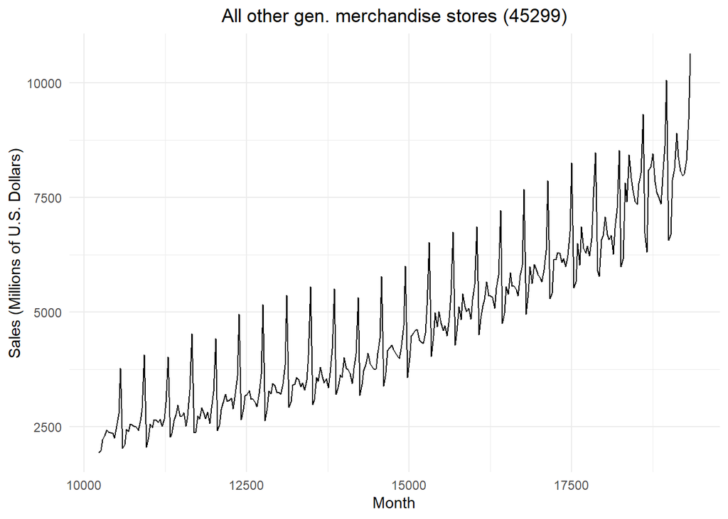

Figure 5: Time plot of the total monthly retail sales for all other general merchandise stores (45299)

```r
# Read in retail sales data for "all other general merchandise stores"
retail_ts <- rio::import("https://byuistats.github.io/timeseries/data/retail_by_business_type.parquet") |>
  filter(naics == 45299) |>
  filter(as_date(month) >= my("Jan 1998")) |>
  as_tsibble(index = month)

retail_ts |>
  autoplot(.vars = sales_millions) +
    labs(
      x = "Month",
      y = "Sales (Millions of U.S. Dollars)",
      title = paste0(retail_ts$business[1], " (", retail_ts$naics[1], ")")
    ) +
    theme_minimal() +
    theme(plot.title = element_text(hjust = 0.5))
```

**TipCheck Your Understanding**

Use Figure 5 to explain the following questions to a partner.

- What is the shape of the trend of this time series?
- Which decomposition would be more appropriate: additive or multiplicative? Justify your answer.
- Apply the appropriate transformation to the time series.
- Fit appropriate models utilizing the indicator terms for seasonal components.
- Determine the “best” model for these data. Justify your decision.
- Check for autocorrelation in the random terms.
- Use AR to fit the model, if there is evidence of autocorrelation in the random component.
- Plot the fitted values and the time series on the same figure.